# Advanced Options for `distfreereg` Package

# Specifying the Test Mean Covariate Argument: Uppercase or Lowercase

When `test_mean` is an `R` function, it has an (optional) argument for the covariates. This argument can be an uppercase `X` or a lowercase `x`. Most examples in other vignettes use the uppercase `X`, since this is the more efficient choice, and suffices in most cases. The uppercase `X` requires, though, that the expressions used in `test_mean` are vectorized.

In the case in which some part of the function is not vectorized, a lowercase `x` can be used. Suppose, for example, that `integrate()` is required to define `test_mean`, and that the covariate value is used as the upper limit of integration. The example below illustrates this using the integral
$$\int_0^x2t\,dt,$$
whose value is known to be $x^2$. We can therefore compare the results of the lowercase example with those of the uppercase example.

```r
set.seed(20240913)
n <- 1e2
func_upper <- function(X, theta) theta[1] + theta[2]*X[,1] + theta[3]*X[,2]^2
func_lower <- function(x, theta) theta[1] + theta[2]*x[1] +
  theta[3]*integrate(function(x) 2*x, lower = 0, upper = x[2])$value
theta <- c(2,5,1)
X <- matrix(rexp(2*n, rate = 1), ncol = 2)
Y <- distfreereg:::f2ftheta(f = func_upper, X)(theta) + rnorm(n)

set.seed(20240913)
dfr_upper <-  distfreereg(Y = Y, X = X, test_mean = func_upper,
                          covariance = list(Sigma = 1), theta_init = c(1,1,1))
set.seed(20240913)
dfr_lower <-  distfreereg(Y = Y, X = X, test_mean = func_lower,
                          covariance = list(Sigma = 1), theta_init = c(1,1,1))

all.equal(dfr_upper$observed_stats, dfr_lower$observed_stats)
```

```
## [1] TRUE
```

```r
all.equal(dfr_upper$p, dfr_lower$p)
```

```
## [1] TRUE
```

# Ordering the Observations

The fundamental object involved in this testing procedure is the *empirical partial sum process* (EPSP); that is, the scaled vector of cumulative sums of transformed residuals. When the model includes only one covariate (that is, when the matrix $X$ of covariates has only one column), the order in which the residuals are added to form this process is determined by the natural linear order of the covariates. When more than one covariate is present, though, no single order is evidently the “correct” one.

## Under the Null Hypothesis

When the null hypothesis is true, the order does not affect the distribution of the statistics of the EPSP (see 4 in Khmaladze (2021)). To illustrate this, consider the following example with only one covariate.

```r
set.seed(20241001)
n <- 1e2
func <- function(X, theta) theta[1] + theta[2]*X[,1]
theta <- c(2,5)
X <- matrix(rexp(n))

cdfr_simplex <- compare(true_mean = func,
                        true_X = X,
                        true_covariance = list(Sigma = 1),
                        theta = theta,
                        test_mean = func,
                        covariance = list(Sigma = 1),
                        X = X,
                        theta_init = c(1,1),
                        keep = 1)
cdfr_asis <- update(cdfr_simplex, ordering = "asis")
```

The order in which the residuals are added is determined by the `ordering` argument of `distfreereg()`. The default method of determining the order is the “simplex” method. In the case of a single covariate, this method orders the observations in increasing order of covariate values. Another built-in option is to preserve to given order of the observations; that is, the order in which the residuals are added is the order of the observations specified in the input to `distfreereg()`. The CDF plots of each method are shown below, and both pairs of curves are mostly overlapping.

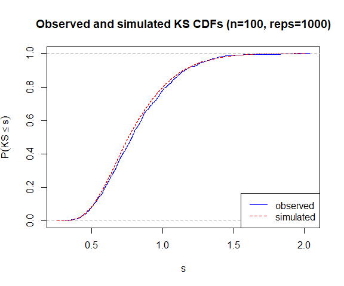

```r
plot(cdfr_simplex)
```

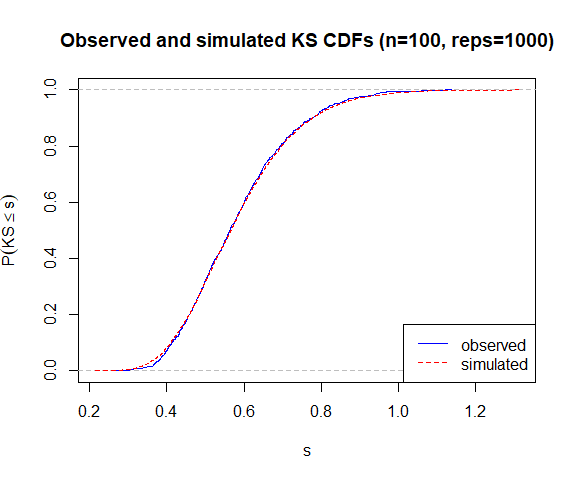

```r
plot(cdfr_asis)
```

## Under an Alternative Hypothesis

When the null hypothesis is false, however, the order of the residuals can have a substantial effect on the power of the test. If the residuals are added in a random order (which they are in the “`asis`” objects, because `X` is randomly generated and not ordered), the test is generally less able to detect deviations from the expected null-hypothesis behavior of the EPSP. Ordering the covariates increases the power of the test to detect such deviations.

To see this in practice, suppose we now change the previous example so that the true mean function has a quadratic term.

```r
alt_func <- function(X, theta) theta[1] + theta[2]*X[,1] + 0.5*X[,1]^2
cdfr_simplex_alt <- update(cdfr_simplex, true_mean = alt_func)
cdfr_asis_alt <- update(cdfr_asis, true_mean = alt_func)
```

The plots below show that the CDFs for the `simplex` method are more separated than those for the `asis` method.

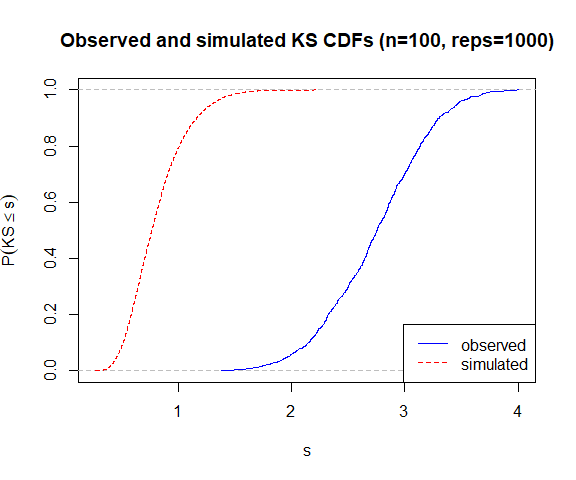

```r
plot(cdfr_simplex_alt)
```

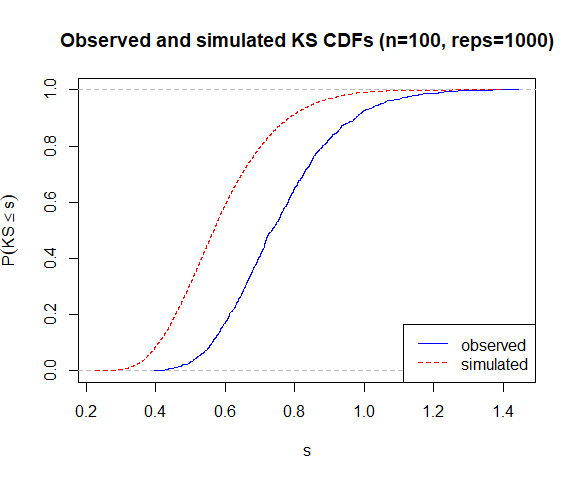

```r
plot(cdfr_asis_alt)
```

The estimated powers of these tests, as expected, highly favor the default `simplex` method:

```r
rejection(cdfr_simplex_alt, stat = "KS")
```

```
##   stat alpha rate mcse
## 1   KS  0.05    1   NA
```

```r
rejection(cdfr_asis_alt, stat = "KS")
```

```
##   stat alpha  rate        mcse
## 1   KS  0.05 0.236 0.004246222
```

## Diagnostic Plots

The previous plots are instructive regarding the importance of ordering, but are not useful when we want to explore model mis-specification. To do that, a plot of the EPSP itself can be helpful. Let us start with the plot from the example above in which the null hypothesis is true.

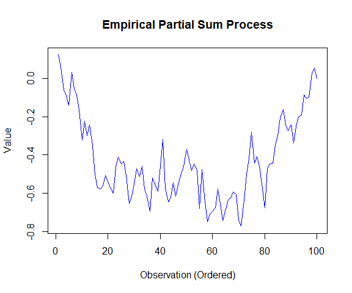

```r
plot(cdfr_simplex$dfrs[[1]], which = "epsp")
```

This plot is a fairly typical representative sample from a Brownian bridge; that is, Brownian motion $B(t)$ on $[0,T]$ subject to the condition that $B(T)=0$.

Now let us look at the plots when the alternative hypothesis is true. First, the plot with residuals ordered in the order of `X`:

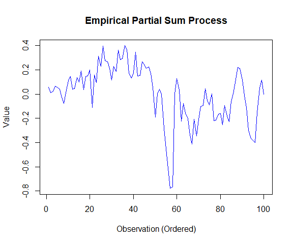

```r
plot(cdfr_asis_alt$dfrs[[1]], which = "epsp")
```

This does not show any patterns that are unexpected from a sample from a Brownian bridge. On the other hand, the plot with the residuals ordered by covariate value show a clear pattern.

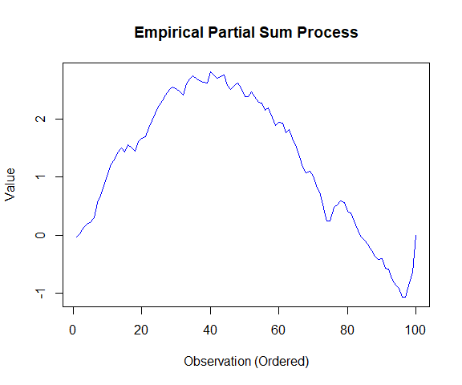

```r
plot(cdfr_simplex_alt$dfrs[[1]], which = "epsp")
```

The slopes of this plot indicate that the residuals are positive, then negative, and then positive again as the covariate values increase. (This is a common trend when a linear function is used to model data with a quadratic mean function.) This patterns can also be seen by looking at the following plot.

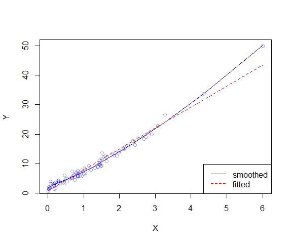

```r
dfr_simplex <- cdfr_simplex_alt$dfrs[[1]]
X <- dfr_simplex$data$X
Y <- dfr_simplex$data$Y[order(X)]
Y_hat <- fitted(dfr_simplex)[order(X)]
X <- sort(X)
ml <- loess(Y ~ X)
plot(X, predict(ml), type = "l", col = "blue", ylab = "Y")
points(X, Y, col = rgb(0,0,1,0.4))
lines(X, Y_hat, col = "red", lty = "dashed")
legend(x = "bottomright", legend = c("smoothed", "fitted"), col = c("blue", "red"),
       lty = c("solid", "dashed"))
```

## Methods

The `asis` option is included primarily for exploratory purposes, and for cases in which observations are given in the desired order. In general, the ordering should arise from a principled mapping of the observations onto the time domain. One such option is provided by the `simplex` method, which scales each covariate to the unit interval, and then orders the observations in increasing order of the sums of their scaled values.

Another option is `optimal`, which orders observations using optimal transport. This is illustrated below. In this example, the power is comparable to the `simplex` method, but the patterns in the EPSP is not as clear.

Note: this method is computationally expensive when the sample size is large.

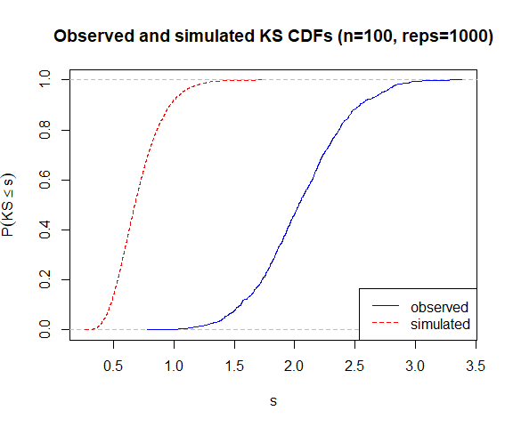

```r
cdfr_optimal_alt <- update(cdfr_simplex_alt, ordering = "optimal")
plot(cdfr_optimal_alt)
```

```r
rejection(cdfr_optimal_alt, stat = "KS")
```

```
##   stat alpha  rate         mcse
## 1   KS  0.05 0.996 0.0006311894
```

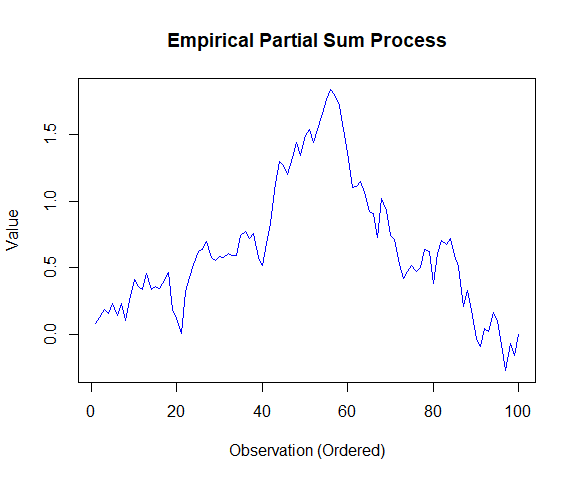

```r
plot(cdfr_optimal_alt$dfrs[[1]], which = "epsp")
```

One more method of ordering is available, which is illustrated in the next section.

# Natural Ordering and Grouping

Another option available for ordering observations is the “natural” ordering, which can also be seen as analogous to a lexicographic ordering: the observations are ordered by covariate values from left to right. That is, observations are ordered in ascending order of the first covariate in the matrix or data frame containing the covariates; ties are broken by ordering by the second covariate; remaining ties are broken by the third; and so on.

In the following example, `Y` is generated using an expression with a quadratic term, but the function being tested is linear in its covariates. We hope that the tests reject the null.

```r
set.seed(20241003)
n <- 1e2
theta <- c(2,5,-1)
X <- cbind(sample(1:5, size = n, replace = TRUE),
           sample(1:10, size = n, replace = TRUE))
Y <- theta[1] + theta[2]*X[,1] + theta[3]*X[,2] + (2e-1)*X[,2]^2 + rnorm(nrow(X))

func <- function(X, theta) theta[1] + theta[2]*X[,1] + theta[3]*X[,2]

dfr <- distfreereg(Y = Y, X = X, test_mean = func, theta_init = c(1,1,1),
                   covariance = list(Sigma = 1), ordering = "natural")
dfr
```

```
##
## Number of observations: 100
## Monte Carlo simulations: 10000
##
## Estimated parameter values:
##     theta1     theta2     theta3
## -3.228e+00  5.358e+00  1.154e+00
##
## Observed statistics:
## Stat      Value  Pr(>Value)       MCSE
##   KS  1.709e+00   2.900e-03  5.377e-04
##  CvM  5.706e-01   2.770e-02  1.641e-03
## ---
## `MCSE' is the Monte Carlo standard error of the estimated p-value.
```

These results can be compared to the `simplex` method.

```r
update(dfr, ordering = "simplex")
```

```
##
## Number of observations: 100
## Monte Carlo simulations: 10000
##
## Estimated parameter values:
##     theta1     theta2     theta3
## -3.228e+00  5.358e+00  1.154e+00
##
## Observed statistics:
## Stat      Value  Pr(>Value)       MCSE
##   KS  1.455e+00   2.110e-02  1.437e-03
##  CvM  5.063e-01   4.070e-02  1.976e-03
## ---
## `MCSE' is the Monte Carlo standard error of the estimated p-value.
```

The results are slightly in favor of the natural ordering in this example.

More flexibility is possible by specifying a list of column names or numbers that will result in the process above being used except only with the listed columns in the listed order.

## Grouping

The previous example’s covariates contain many repeated observations. When using the natural ordering (or any other), these observations are indistinguishable, and their order among themselves is dependent on the order in which they happen to appear in `X`. To avoid this arbitrariness in the calculation of test statistics, a grouping option is available. When the `group` argument is `TRUE`, the transformed residuals for repeated covariate values are added before forming the EPSP. This avoids dependence on the order in which the observations enter the data. To implement this, we can update `dfr` as follows.

```r
dfr_grouped <- update(dfr, group = TRUE)
```

Note that the length of `epsp` is no longer the sample size. It is instead the number of unique combinations of values in the two columns of `X`.

```r
length(dfr_grouped$epsp)
```

```
## [1] 44
```

```r
length(which(table(X[,1], X[,2]) > 0))
```

```
## [1] 44
```

The test results are similar, but not identical to, those in `dfr`.

```r
dfr_grouped
```

```
##
## Number of observations: 100
## Monte Carlo simulations: 10000
##
## Estimated parameter values:
##     theta1     theta2     theta3
## -3.228e+00  5.358e+00  1.154e+00
##
## Observed statistics:
## Stat      Value  Pr(>Value)       MCSE
##   KS  1.372e+00   1.750e-02  1.311e-03
##  CvM  3.888e-01   6.180e-02  2.408e-03
## ---
## `MCSE' is the Monte Carlo standard error of the estimated p-value.
```

# The `override` Argument

The `override` argument of `distfreereg()` is used by `update.distfreereg()` to avoid unnecessary recalculation. This has particular benefits for the performance of `compare()`, which uses `update.distfreereg()`.

This argument can be useful in other cases, too. For example, if the observations should be ordered in a way that is not among the available options for `ordering`, this order can be specified using `res_order`.

The example below illustrates a more involved application. To access the `override` argument directly when using `compare()`, the `global_override` argument is used. Any values supplied to this argument are passed to `override` in each repetition’s call to `update.distfreereg()`. Let us use this below to show the (possibly surprising) result of using the true value of $\theta$ instead of $\hat\theta$, even with a very simple setup.

```r
set.seed(20241003)
n <- 2e2
func <- function(X, theta) theta[1] + theta[2]*X[,1]
theta <- c(2,5)
X <- matrix(rexp(n))

cdfr <- compare(true_mean = func, test_mean = func, true_X = X, X = X,
                true_covariance = list(Sigma = 1), covariance = list(Sigma = 1),
                theta = theta, theta_init = c(1,1))
cdfr_theta <- update(cdfr, global_override = list(theta_hat = theta))
```

The first plot is what we expect, given that the true mean and test mean are the same in `cdfr`:

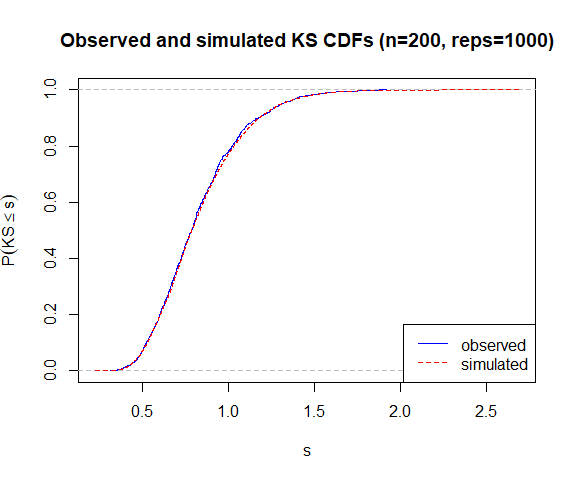

```r
plot(cdfr)
```

However, the next plot shows that using $\theta$ does not yield good results:

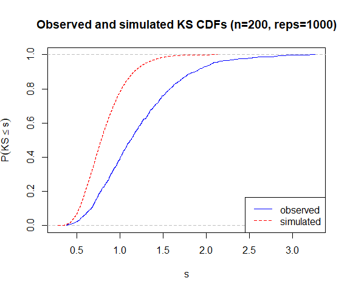

```r
plot(cdfr_theta)
```

# References

Khmaladze, E. V. (2021), “Distribution-free testing in linear and parametric regression,” *Annals of the Institute of Statistical Mathematics*, Springer Science; Business Media LLC, 73, 1063–1087. https://doi.org/10.1007/s10463-021-00786-3.